# diabetes_prediction

```python
import pandas as pd
import numpy as np
import matplotlib.pyplot as plt
import seaborn as sns
```

```python
import warnings
warnings.filterwarnings('ignore')
```

### Part 1 : Importing Dataset and Overview

Dataset url : https://www.kaggle.com/uciml/pima-indians-diabetes-database

```python
df = pd.read_csv('diabetes.csv')
df
```

|  | Pregnancies | Glucose | BloodPressure | SkinThickness | Insulin | BMI | DiabetesPedigreeFunction | Age | Outcome |
| --- | --- | --- | --- | --- | --- | --- | --- | --- | --- |
| 0 | 6 | 148 | 72 | 35 | 0 | 33.6 | 0.627 | 50 | 1 |
| 1 | 1 | 85 | 66 | 29 | 0 | 26.6 | 0.351 | 31 | 0 |
| 2 | 8 | 183 | 64 | 0 | 0 | 23.3 | 0.672 | 32 | 1 |
| 3 | 1 | 89 | 66 | 23 | 94 | 28.1 | 0.167 | 21 | 0 |
| 4 | 0 | 137 | 40 | 35 | 168 | 43.1 | 2.288 | 33 | 1 |
| ... | ... | ... | ... | ... | ... | ... | ... | ... | ... |
| 763 | 10 | 101 | 76 | 48 | 180 | 32.9 | 0.171 | 63 | 0 |
| 764 | 2 | 122 | 70 | 27 | 0 | 36.8 | 0.340 | 27 | 0 |
| 765 | 5 | 121 | 72 | 23 | 112 | 26.2 | 0.245 | 30 | 0 |
| 766 | 1 | 126 | 60 | 0 | 0 | 30.1 | 0.349 | 47 | 1 |
| 767 | 1 | 93 | 70 | 31 | 0 | 30.4 | 0.315 | 23 | 0 |

768 rows × 9 columns

The dataset is provided by Pima Indians Diabetes Database and use following features to predict the outcome

- **Pregnancies** : No. of times pregnant
- **Glucose** : Plasma glucose concentration a 2 hours in an oral glucose tolerance test
- **BloodPressure** : Diastolic blood pressure (mm Hg)
- **SkinThickness** : Triceps skin fold thickness (mm)
- **Insulin** : 2-Hour serum insulin (mu U/ml)
- **BMI** : Body mass index (weight in kg/(height in m)^2
- **DiabetesPedigreeFunction** : Calculates diabetes likelihood depending on the subject's age and his/her diabetic family history
- **Age** : Age (years)

```python
df.shape
```

```
(768, 9)
```

```python
df.describe()
```

|  | Pregnancies | Glucose | BloodPressure | SkinThickness | Insulin | BMI | DiabetesPedigreeFunction | Age | Outcome |
| --- | --- | --- | --- | --- | --- | --- | --- | --- | --- |
| count | 768.000000 | 768.000000 | 768.000000 | 768.000000 | 768.000000 | 768.000000 | 768.000000 | 768.000000 | 768.000000 |
| mean | 3.845052 | 120.894531 | 69.105469 | 20.536458 | 79.799479 | 31.992578 | 0.471876 | 33.240885 | 0.348958 |
| std | 3.369578 | 31.972618 | 19.355807 | 15.952218 | 115.244002 | 7.884160 | 0.331329 | 11.760232 | 0.476951 |
| min | 0.000000 | 0.000000 | 0.000000 | 0.000000 | 0.000000 | 0.000000 | 0.078000 | 21.000000 | 0.000000 |
| 25% | 1.000000 | 99.000000 | 62.000000 | 0.000000 | 0.000000 | 27.300000 | 0.243750 | 24.000000 | 0.000000 |
| 50% | 3.000000 | 117.000000 | 72.000000 | 23.000000 | 30.500000 | 32.000000 | 0.372500 | 29.000000 | 0.000000 |
| 75% | 6.000000 | 140.250000 | 80.000000 | 32.000000 | 127.250000 | 36.600000 | 0.626250 | 41.000000 | 1.000000 |
| max | 17.000000 | 199.000000 | 122.000000 | 99.000000 | 846.000000 | 67.100000 | 2.420000 | 81.000000 | 1.000000 |

Some errors like zero glucose, bloodpressure, skinthickness, insulin, BMI can be seen which represents missing data.

```python
df.isnull().sum()
```

```
Pregnancies                 0
Glucose                     0
BloodPressure               0
SkinThickness               0
Insulin                     0
BMI                         0
DiabetesPedigreeFunction    0
Age                         0
Outcome                     0
dtype: int64
```

There is no *null* values in the dataset

### Part 2 : Visualization

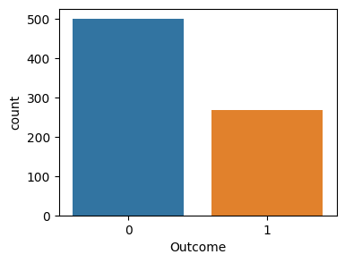

```python
plt.figure(figsize=(4, 3))
sns.countplot(x = 'Outcome',data = df)
```

The dataset is imbalanced, as number of patients who don't have diabetes is more than those who do.

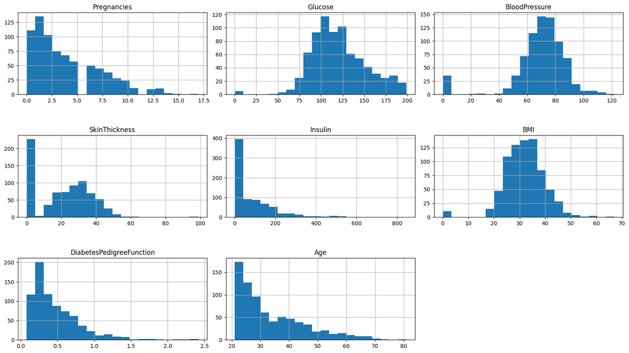

```python
import itertools

col = df.columns[:8]
plt.subplots(figsize = (20, 15))
length = len(col)

for i, j in itertools.zip_longest(col, range(length)):
    plt.subplot(int(length/2), 3, j + 1)
    plt.subplots_adjust(wspace = 0.1,hspace = 0.5)
    df[i].hist(bins = 20)
    plt.title(i)


plt.show()
```

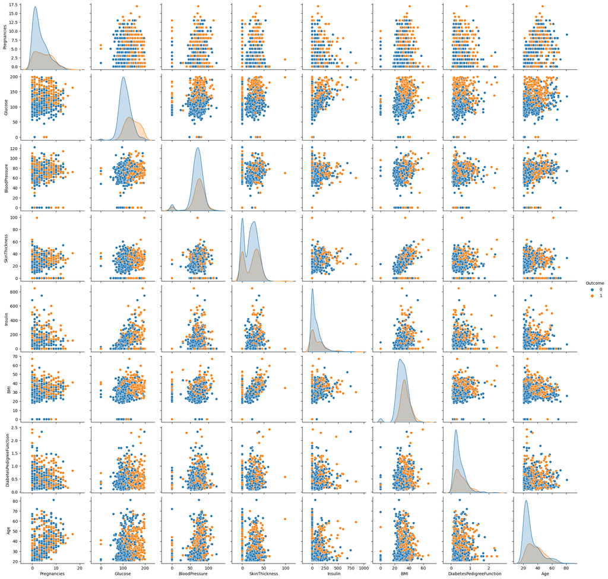

```python
sns.pairplot(data = df, hue = 'Outcome')
plt.show()
```

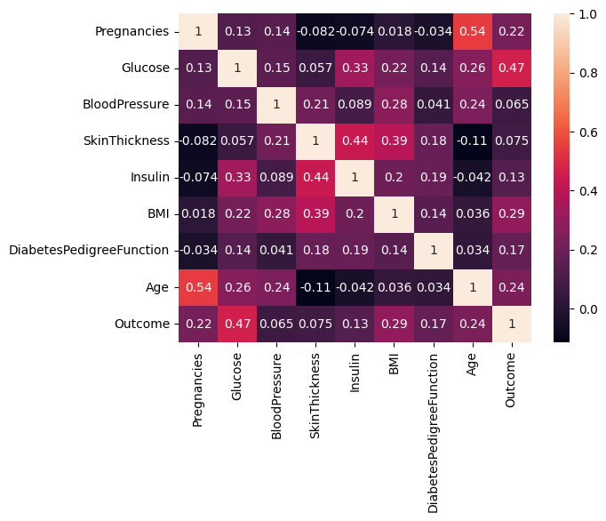

```python
sns.heatmap(df.corr(), annot = True)
plt.show()
```

### Part 3 : Processing

```python
df1 = df[['Glucose', 'BMI', 'Age', 'Insulin', 'Outcome']]
df1
```

|  | Glucose | BMI | Age | Insulin | Outcome |
| --- | --- | --- | --- | --- | --- |
| 0 | 148 | 33.6 | 50 | 0 | 1 |
| 1 | 85 | 26.6 | 31 | 0 | 0 |
| 2 | 183 | 23.3 | 32 | 0 | 1 |
| 3 | 89 | 28.1 | 21 | 94 | 0 |
| 4 | 137 | 43.1 | 33 | 168 | 1 |
| ... | ... | ... | ... | ... | ... |
| 763 | 101 | 32.9 | 63 | 180 | 0 |
| 764 | 122 | 36.8 | 27 | 0 | 0 |
| 765 | 121 | 26.2 | 30 | 112 | 0 |
| 766 | 126 | 30.1 | 47 | 0 | 1 |
| 767 | 93 | 30.4 | 23 | 0 | 0 |

768 rows × 5 columns

```python
#Replacing zeros with null
df1[["Glucose", "Insulin", "BMI"]] = df1[["Glucose", "Insulin", "BMI"]].replace(0, np.NaN)
```

```python
df1.isnull().sum()
```

```
Glucose      5
BMI         11
Age          0
Insulin    374
Outcome      0
dtype: int64
```

```python
#Replacing zeros with mean
df1['Glucose'].fillna(df1['Glucose'].mean(), inplace = True)
df1['BMI'].fillna(df1['BMI'].mean(), inplace = True)
df1['Insulin'].fillna(df1['Insulin'].mean(), inplace = True)
```

```python
df1.isnull().sum()
```

```
Glucose    0
BMI        0
Age        0
Insulin    0
Outcome    0
dtype: int64
```

```python
# from sklearn.preprocessing import MinMaxScaler
# sc = MinMaxScaler(feature_range = (0, 1))
# df2 = pd.DataFrame(sc.fit_transform(df1))
# df2
```

```python
X = df1[["Glucose", "Insulin", "BMI", "Age"]]
y = df1[['Outcome']]
```

```python
from sklearn.model_selection import train_test_split
X_train, X_test, y_train, y_test = train_test_split(X, y, test_size = 0.20)
```

```python
print(X_train.shape, X_test.shape, len(y_train), len(y_test))
```

```
(614, 4) (154, 4) 614 154
```

### Part 4 : Modelling

We will use different models to classify whether a patient having a set of given features has diabetes or not.

```python
# Logistic Regression
from sklearn.linear_model import LogisticRegression
logreg = LogisticRegression()
logreg.fit(X_train, y_train)
logreg.score(X_test, y_test)
```

```
0.7727272727272727
```

```python
#SVM
from sklearn.svm import SVC
svm = SVC()
svm.fit(X_train, y_train)
svm.score(X_test, y_test)
```

```
0.7337662337662337
```

```python
#Desc Trees
from sklearn import tree
desctree = tree.DecisionTreeClassifier()
desctree.fit(X_train, y_train)
desctree.score(X_test, y_test)
```

```
0.7662337662337663
```

```python
#Random Forest
from sklearn.ensemble import RandomForestClassifier
rdm_frst = RandomForestClassifier()
rdm_frst.fit(X_train, y_train)
rdm_frst.score(X_test, y_test)
```

```
0.7467532467532467
```

```python
#Knn
from sklearn.neighbors import KNeighborsClassifier
knn = KNeighborsClassifier()
knn.fit(X_train, y_train)
knn.score(X_test, y_test)
```

```
0.7402597402597403
```

```python
#Naive Bayes
from sklearn.naive_bayes import GaussianNB
nb = GaussianNB()
nb.fit(X_train,y_train)
nb.score(X_test, y_test)
```

```
0.7792207792207793
```

We can see accuracies of all the 6 models.  
Logistic Regression and Naive Bayes are most successfull models, but we've to check by tuning the paramenters of each model if we can get better out of them.

### Part 5 : Parameters Tuning

```python
from sklearn.model_selection import GridSearchCV
from sklearn.model_selection import ShuffleSplit
```

```python
def best_model(X, y):
    algos = {
        'logistic_regression' : {
            'model' : LogisticRegression(),
            'params' : {
                'fit_intercept' : [True, False]
            }
        },

        'svm' : {
            'model' : SVC(),
            'params' : {
                'C': [0.1, 1, 10, 100],
                'degree' : [3,4],
                'kernel' : ['linear', 'poly', 'rbf', 'sigmoid']
            }
        },

        'desc_trees' : {
            'model' : tree.DecisionTreeClassifier(),
            'params' : {
                'criterion' : ['gini', 'entropy', 'log_loss'],
                'splitter' : ['random', 'best']
            }
        },

        'random_forest' : {
            'model' : RandomForestClassifier(),
            'params' : {
                'n_estimators' : [50, 70, 100, 120 ],
                'criterion' : ['gini', 'entropy', 'log_loss']
            }
        },

        'knn' : {
            'model' : KNeighborsClassifier(),
            'params' : {
                'n_neighbors' : [5, 7, 10, 15, 20],
                'weights' : ['uniform', 'distance']
            }
        },

        'naive_bayes' : {
            'model' : GaussianNB(),
            'params' : {
            }
        }
    }

    scores = []
    cv = cv = ShuffleSplit(n_splits=5, test_size=0.2, random_state=0)

    for algo_name, config in algos.items():
        gs = GridSearchCV(config['model'],config['params'],cv=cv, return_train_score = False)
        gs.fit(X,y)

        scores.append({
            'model' : algo_name,
            'best_score' : gs.best_score_,
            'best_params' : gs.best_params_
        })

    return pd.DataFrame(scores,columns=['model','best_score','best_params'])
```

```python
best_model(X,y)
```

|  | model | best_score | best_params |
| --- | --- | --- | --- |
| 0 | logistic_regression | 0.780519 | {'fit_intercept': True} |
| 1 | svm | 0.785714 | {'C': 0.1, 'degree': 3, 'kernel': 'linear'} |
| 2 | desc_trees | 0.693506 | {'criterion': 'entropy', 'splitter': 'best'} |
| 3 | random_forest | 0.776623 | {'criterion': 'entropy', 'n_estimators': 50} |
| 4 | knn | 0.767532 | {'n_neighbors': 15, 'weights': 'uniform'} |
| 5 | naive_bayes | 0.771429 | {} |

From the above data we can see the most suitable model to use is Support Vector Machines with parameters 'C': 0.1, 'degree': 3, 'kernel': 'linear'

```python
selected_model =  SVC( C =0.1, degree = 3, kernel = 'linear')
selected_model.fit(X_train, y_train)
y_predicted = selected_model.predict(X_test)
```

```python
selected_model.score(X_test, y_test)
```

```
0.7727272727272727
```

```python
from sklearn.metrics import confusion_matrix
cm = confusion_matrix(y_test, y_predicted)
cm
```

```
array([[88,  8],
       [27, 31]], dtype=int64)
```

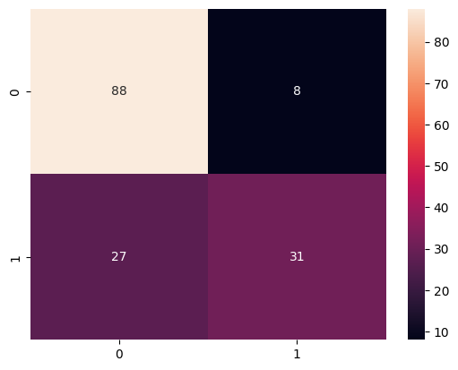

```python
sns.heatmap(pd.DataFrame(cm), annot=True)
```

```python
import pickle
pickle.dump(selected_model, open('model.pkl', 'wb'))
model = pickle.load(open('model.pkl', 'rb'))
```